# T Distribution

2022-10-18

## The t-distribution

- Above we made use of the CLT with a sample size of 15.
- Because we are estimating a second parameters \(\sigma\), further variability is introduced into our confidence interval which results in intervals that are too small.

## The t-distribution

- For very large sample sizes this extra variability is negligible, but, in general, for values smaller than 30 we need to be cautious about using the CLT.
- However, if the data in the urn is known to follow a normal distribution, then we actually have mathematical theory that tells us how much bigger we need to make the intervals to account for the estimation of \(\sigma\).
- Using this theory, we can construct confidence intervals for any \(N\).
- But again, this works only if **the data in the urn is known to follow a normal distribution**.
- So for the 0, 1 data of our previous urn model, this theory definitely does not apply.

## The t-distribution

- The statistic on which confidence intervals for \(d\) are based is.

\[ Z = \frac{\bar{X} - d}{\sigma/\sqrt{N}} \]

- CLT tells us that Z is approximately normally distributed with expected value 0 and standard error 1.
- But in practice we don’t know \(\sigma\) so we use:

\[ t = \frac{\bar{X} - d}{s/\sqrt{N}} \]

- This is referred to a *t-statistic*.

## The t-distribution

- By substituting \(\sigma\) with \(s\) we introduce some variability.
- The theory tells us that \(t\) follows a *student t-distribution* with \(N-1\) *degrees of freedom*.
- The degrees of freedom is a parameter that controls the variability via fatter tails:

## The t-distribution

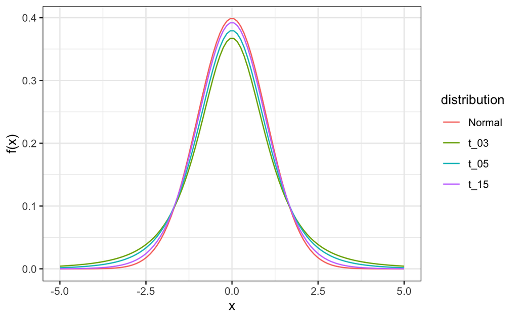

## The t-distribution

- If we are willing to assume the pollster effect data is normally distributed, based on the sample data \(X_1, \dots, X_N\),

```r
one_poll_per_pollster |>
  ggplot(aes(sample=spread)) + stat_qq()
```

## The t-distribution

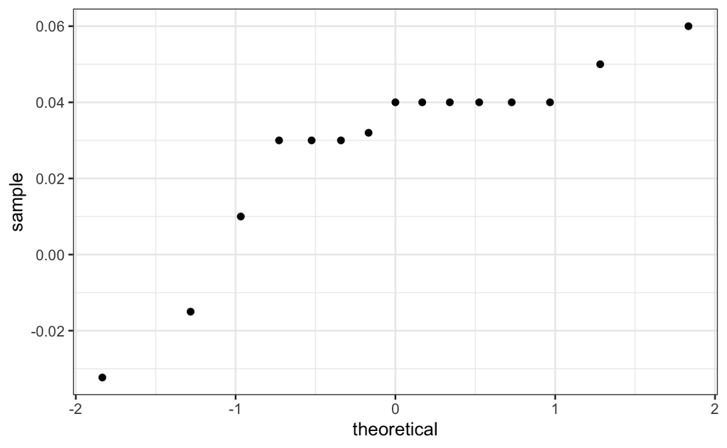

## The t-distribution

- then \(t\) follows a t-distribution with \(N-1\) degrees of freedom.
- So perhaps a better confidence interval for \(d\) is:

```r
z <- qt(0.975,  nrow(one_poll_per_pollster)-1)
one_poll_per_pollster |>
  summarize(avg = mean(spread),
            moe = z*sd(spread)/sqrt(length(spread))) |>
  mutate(start = avg - moe, end = avg + moe)
```

```
#> # A tibble: 1 × 4
#>      avg    moe  start    end
#>    <dbl>  <dbl>  <dbl>  <dbl>
#> 1 0.0290 0.0134 0.0156 0.0424
```

## The t-distribution

- A bit larger than the one using normal is.

```r
qt(0.975, 14)
```

```
#> [1] 2.14
```

- is bigger than.

```r
qnorm(0.975)
```

```
#> [1] 1.96
```

- Using the t-distribution and the t-statistic is the basis for *t-tests*, widely used approach for computing p-values.

## The t-distribution

- To learn more about t-tests, you can consult any statistics textbook.
- The t-distribution can also be used to model errors in bigger deviations that are more likely than with the normal distribution, as seen in the densities we previously saw.
- Fivethirtyeight uses the t-distribution to generate errors that better model the deviations we see in election data.
- For example, in Wisconsin the average of six polls was 7% in favor of Clinton with a standard deviation of 1%, but Trump won by 0.7%.
- Even after taking into account the overall bias, this 7.7% residual is more in line with t-distributed data than the normal distribution.

```r
## The t-distribution

data("polls_us_election_2016")
polls_us_election_2016 |>
  filter(state =="Wisconsin" &
           enddate >="2016-10-31" &
           (grade %in% c("A+","A","A-","B+") | is.na(grade))) |>
  mutate(spread = rawpoll_clinton/100 - rawpoll_trump/100) |>
  mutate(state = as.character(state)) |>
  left_join(results_us_election_2016, by = "state") |>
  mutate(actual = clinton/100 - trump/100) |>
  summarize(actual = first(actual), avg = mean(spread),
            sd = sd(spread), n = n()) |>
  select(actual, avg, sd, n)
```

```
#>   actual    avg     sd n
#> 1 -0.007 0.0711 0.0104 6
```